# Master in Statistics and Data Science

Programming in R: Practical session 2

Student: Quynh Long Khuong

Hasselt, Belgium, 15 October 2021

[figure not shown]

```r
library(tidyverse)
```

# Question 1

**In this question we focus on the `airquality` data which available as data frame in R. Use `help(airquality)` to get information about the data**

```r
data("airquality")
head(airquality)
```

```
##   Ozone Solar.R Wind Temp Month Day
## 1    41     190  7.4   67     5   1
## 2    36     118  8.0   72     5   2
## 3    12     149 12.6   74     5   3
## 4    18     313 11.5   62     5   4
## 5    NA      NA 14.3   56     5   5
## 6    28      NA 14.9   66     5   6
```

## Q1.1

**1. Define an R object which contain the information about the wind speed**

```r
wind_speed <- airquality$Wind
```

## Q1.2

**2. Calculate the mean, median and variance for the wind speed**

```r
sprintf("Wind speed: mean = %.2f; median = %2.f; and variance = %.2f",
        mean(wind_speed), median(wind_speed), var(wind_speed))
```

```
## [1] "Wind speed: mean = 9.96; median = 10; and variance = 12.41"
```

## Q1.3

**3. Produce the figure below**

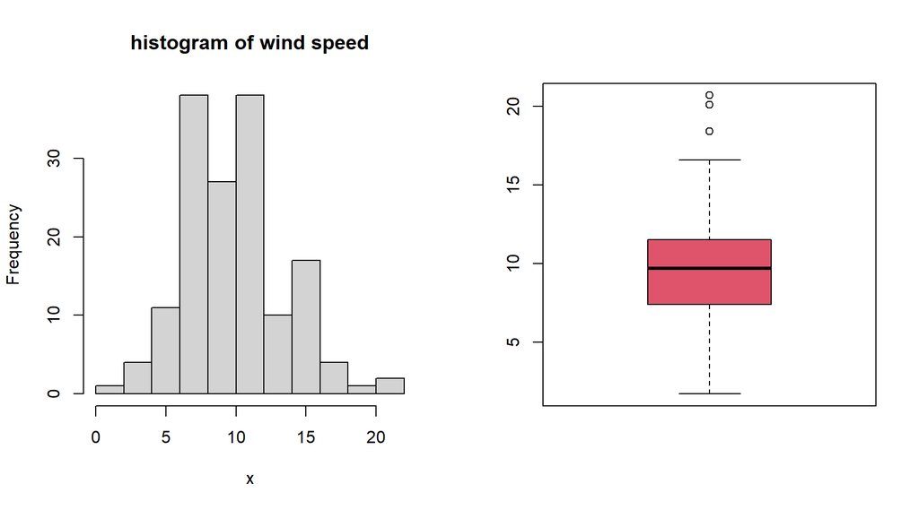

```r
par(mfrow = c(1, 2))
hist(wind_speed, main = "histogram of wind speed", xlab = "x")
boxplot(wind_speed, ylab = NULL, xlab = NULL, col = "#df536b")
```

# Question 2

**In this question we focus on the `ToothGrowth` data which available as data frame in R. Use `help(ToothGrowth)` to get information about the data**

```r
data("ToothGrowth")
head(ToothGrowth)
```

```
##    len supp dose
## 1  4.2   VC  0.5
## 2 11.5   VC  0.5
## 3  7.3   VC  0.5
## 4  5.8   VC  0.5
## 5  6.4   VC  0.5
## 6 10.0   VC  0.5
```

## Q2.1

**1. The response variable is the Tooth length**

```r
tooth_length <- ToothGrowth$len
```

## Q2.2

**2. Test if the Supplement type has an effect on the tooth length**

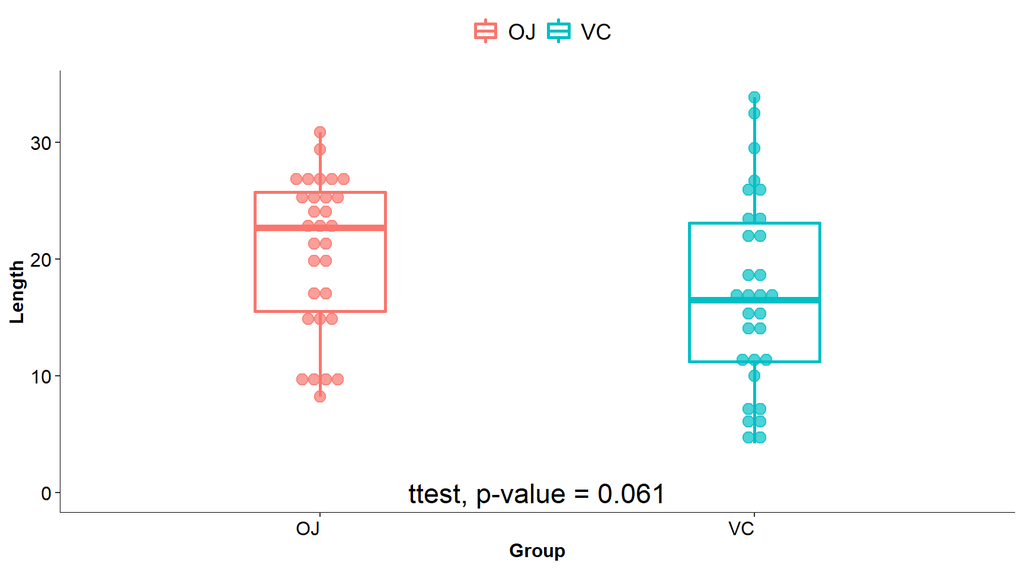

```r
x <- t.test(ToothGrowth$len ~ ToothGrowth$supp)
ToothGrowth %>%
  ggplot(aes(x = supp, y = len)) +
  geom_dotplot(aes(color = supp, fill = supp) ,binaxis='y',
                 stackdir='center',
                 dotsize = 0.9,
                 alpha = 0.7, show.legend = F) +
  geom_boxplot(aes(color = supp), width = 0.3, fill = NA, size = 1) +
  annotate("text", x = 1.5, y = 0,
           label = paste0("ttest, ", "p-value = ", round(x$p.value, 3)), size = 6) +
  theme_bw() +
      theme(
        panel.grid.major = element_blank(),
        panel.grid.minor = element_blank(),
        panel.border = element_blank(),
        axis.line = element_line(size = 0.3),
        axis.text = element_text(size = 12, color = "black", hjust=1),
        axis.title = element_text(face = "bold", size = 12, color = "black"),
        plot.title = element_text(face = "bold", size = 14, color = "black", hjust = 0.5),
        legend.position = "top",
        legend.text = element_text(size = 14)
    ) +
    labs(
        x = "Group",
        y = "Length",
        color = NULL
    )
```

# Question 3

**For the `ToothGrowth` data, produce an histogram for the tooth length (by group) with the following structure.**

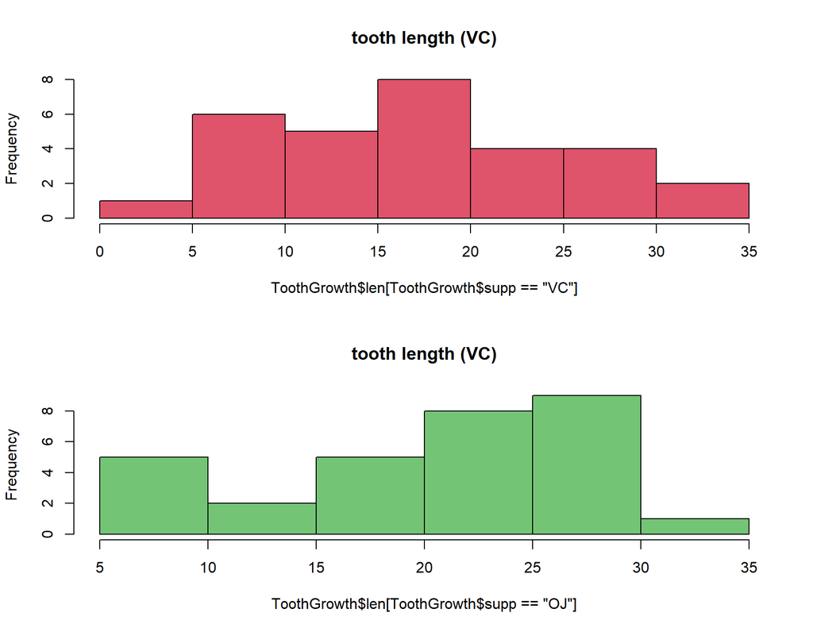

```r
par(mfrow = c(2, 1))
hist(ToothGrowth$len[ToothGrowth$supp == "VC"], main = "tooth length (VC)", col = "#df536b")
hist(ToothGrowth$len[ToothGrowth$supp == "OJ"], main = "tooth length (VC)", col = "#74c476")
```

# Question 4

**Create the following data frame:**

```
##   Name Gender Height
## 1    A      M    180
## 2    B      M    170
## 3    C      F    170
## 4    D      F    155
## 5    E      F    167
## 6    F      F    154
```

```r
Name <- c("A", "B", "C", "D", "E", "F")
Gender <- c("M", "M", "F", "F", "F", "F")
Height <- c(180, 170, 170, 155, 167, 154)

df_q4 <- data.frame(Name, Gender, Height)
df_q4
```

```
##   Name Gender Height
## 1    A      M    180
## 2    B      M    170
## 3    C      F    170
## 4    D      F    155
## 5    E      F    167
## 6    F      F    154
```

# Question 5

**In this question we focus on the `chickwts` data which available as data frame in R. Use `help(chickwts)` to get information about the data.**

```r
data("chickwts")
head(chickwts)
```

```
##   weight      feed
## 1    179 horsebean
## 2    160 horsebean
## 3    136 horsebean
## 4    227 horsebean
## 5    217 horsebean
## 6    168 horsebean
```

## Q5.1

**Create a new data frame which contains data only of the `horsebean` and the `soybean` groups. How many observations are included in the new dataset**

```r
table(chickwts$feed)
```

```
##
##    casein horsebean   linseed  meatmeal   soybean sunflower
##        12        10        12        11        14        12
```

```r
chick_hors_soy <- chickwts %>% filter(feed %in% c("horsebean", "soybean"))
```

## Q5.2

**Calculate the mean and standard deviation of the weight by group**

```r
chick_hors_soy %>% group_by(feed) %>% summarise(Mean = mean(weight),
                                                SD = sd(weight))
```

```
## # A tibble: 2 x 3
##   feed       Mean    SD
## * <fct>     <dbl> <dbl>
## 1 horsebean  160.  38.6
## 2 soybean    246.  54.1
```